# Linear_Regression

Matthew Gregory

Tuesday, September 22, 2015

We are interested in predicting the price of a diamond based on 9 predictors. We want to know if we are getting ripped off for the price we pay for a diamond compared to historical prices.  
First we load the appropriate libraries (makes sure you have them installed).

Then we read in the diamonds data and assign it to an object called `mydata`. We inspect the structure of the dataframe using `str`.

```
## 'data.frame':    53940 obs. of  10 variables:
##  $ carat  : num  0.23 0.21 0.23 0.29 0.31 0.24 0.24 0.26 0.22 0.23 ...
##  $ cut    : Ord.factor w/ 5 levels "Fair"<"Good"<..: 5 4 2 4 2 3 3 3 1 3 ...
##  $ color  : Ord.factor w/ 7 levels "D"<"E"<"F"<"G"<..: 2 2 2 6 7 7 6 5 2 5 ...
##  $ clarity: Ord.factor w/ 8 levels "I1"<"SI2"<"SI1"<..: 2 3 5 4 2 6 7 3 4 5 ...
##  $ depth  : num  61.5 59.8 56.9 62.4 63.3 62.8 62.3 61.9 65.1 59.4 ...
##  $ table  : num  55 61 65 58 58 57 57 55 61 61 ...
##  $ price  : int  326 326 327 334 335 336 336 337 337 338 ...
##  $ x      : num  3.95 3.89 4.05 4.2 4.34 3.94 3.95 4.07 3.87 4 ...
##  $ y      : num  3.98 3.84 4.07 4.23 4.35 3.96 3.98 4.11 3.78 4.05 ...
##  $ z      : num  2.43 2.31 2.31 2.63 2.75 2.48 2.47 2.53 2.49 2.39 ...
```

The dataframe seems to have the factors in the correct order and numerical variables assigned as such.

```r
#WARNING takes a 10 minutes to run!
#diasamp <- mydata[sample(1:length(mydata$price), 10000),]
#ggpairs(diasamp, params = c(shape = I("."), outlier.shape = I(".")))
```

Let’s define a function to inspect the cube root of the carat, it’s volume.

```r
cubroot_trans = function() trans_new("cubroot", transform= function(x) x^(1/3), inverse = function(x) x^3 )
```

With so many data points overfitting is a concern, let’s jitter and make each point more transparent.

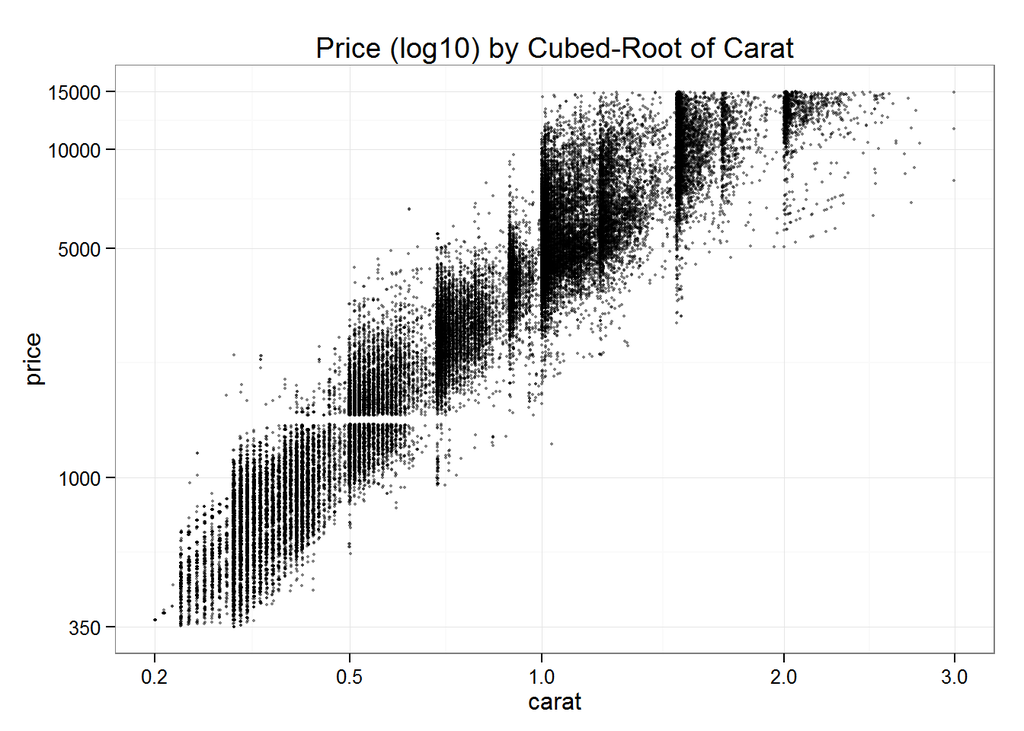

```r
p1 <- ggplot( data=mydata, aes(carat, price)) +
    geom_point(alpha = 0.5, size = .75, position="jitter") +
    scale_x_continuous(trans=cubroot_trans(), limits = c(0.2,3),
        breaks = c(0.2, 0.5, 1, 2, 3)) +
    scale_y_continuous(trans=log10_trans(), limits = c(350,15000),
        breaks = c(350, 1000, 5000, 10000, 15000)) +
    theme_bw() +
    ggtitle("Price (log10) by Cubed-Root of Carat")
p1
```

Our 2008 data has some problems but let’s go ahead and model price using linear regression.

```r
mydata$logprice <- log(mydata$price)
m1 <- lm(logprice~  I(carat^(1/3)),
    data=mydata[mydata$price < 10000,])
m2 <- update(m1, ~ . + carat)
m3 <- update(m2, ~ . + cut )
m4 <- update(m3, ~ . + color + clarity)


mtable(m1, m2, m3, m4)
```

```
##
## Calls:
## m1: lm(formula = logprice ~ I(carat^(1/3)), data = mydata[mydata$price <
##     10000, ])
## m2: lm(formula = logprice ~ I(carat^(1/3)) + carat, data = mydata[mydata$price <
##     10000, ])
## m3: lm(formula = logprice ~ I(carat^(1/3)) + carat + cut, data = mydata[mydata$price <
##     10000, ])
## m4: lm(formula = logprice ~ I(carat^(1/3)) + carat + cut + color +
##     clarity, data = mydata[mydata$price < 10000, ])
##
## ===========================================================
##                     m1         m2         m3         m4
## -----------------------------------------------------------
## (Intercept)      2.723***   0.653***   0.538***   0.340***
##                 (0.007)    (0.027)    (0.026)    (0.014)
## I(carat^(1/3))   5.667***   9.327***   9.383***   9.311***
##                 (0.008)    (0.046)    (0.045)    (0.025)
## carat                      -1.551***  -1.540***  -1.194***
##                            (0.019)    (0.019)    (0.010)
## cut: .L                                0.206***   0.119***
##                                       (0.004)    (0.002)
## cut: .Q                               -0.057***  -0.031***
##                                       (0.004)    (0.002)
## cut: .C                                0.046***   0.012***
##                                       (0.003)    (0.002)
## cut: ^4                                0.015***  -0.004**
##                                       (0.003)    (0.001)
## color: .L                                        -0.425***
##                                                  (0.002)
## color: .Q                                        -0.092***
##                                                  (0.002)
## color: .C                                        -0.015***
##                                                  (0.002)
## color: ^4                                         0.014***
##                                                  (0.002)
## color: ^5                                         0.001
##                                                  (0.002)
## color: ^6                                         0.001
##                                                  (0.001)
```

[output cut: 11 more lines]

```
##                                                  (0.002)
## clarity: ^7                                       0.031***
##                                                  (0.001)
## -----------------------------------------------------------
## R-squared            0.913      0.923      0.928      0.979
## adj. R-squared       0.913      0.923      0.928      0.979
## sigma                0.261      0.246      0.238      0.127
## F               512971.707 293367.406 104526.210 122132.105
## p                    0.000      0.000      0.000      0.000
## Log-likelihood   -3713.458   -707.428    796.643  31356.349
## Deviance          3322.113   2936.426   2760.594    787.309
## AIC               7432.916   1422.856  -1577.286 -62670.699
## BIC               7459.297   1458.031  -1506.936 -62486.029
## N                48717      48717      48717      48717
## ===========================================================
```

We can use the `summary` function on each of these models to assess how much variation within the data they explain.

We can use the model to see if we are being charged too much for a diamond we are interested in.

```r
# Round 1.00 Very Good I VS1 $5,601
thisDiamond <- data.frame(carat = 1.00, cut = "Very Good", color = "I", clarity="VS1")
modEst <- predict(m4, newdata = thisDiamond, interval="prediction", level = .95)
exp(modEst)
```

```
##        fit      lwr      upr
## 1 4495.173 3503.397 5767.712
```